# 📌 Extract: O E do ETL

Como falamos na aula de ferramentas, o processo é o mesmo independente da ferramenta. Para efeito de comparação, faremos as mesmas operações no Google Planilhas e no Python, as quais também podem ser feitas (e foram feitas ao longo do curso) no PowerBI.

[figure not shown]

```python
import pandas as pd
import numpy as np
```

## 1️⃣ Lendo em excel

```python
# Lendo um arquivo Excel (substitua pelo caminho real do arquivo)
# pd é o apelido que demos para pandas e read_excel é uma função do pandas
# estamos lendo o excel e o atribuindo a um dataframe (uma tabela)

df = pd.read_excel("/content/Cópia de Dados - TCC - Planilhas.xlsx")
```

```python
#Se rodar df, o dataframe será chamado

df
```

|  | Unnamed: 0 | Unnamed: 1 | Unnamed: 2 |
| --- | --- | --- | --- |
| 0 | NaN | NaN | NaN |
| 1 | NaN | NaN | NaN |
| 2 | NaN | NaN | NaN |
| 3 | NaN | NaN | NaN |
| 4 | Dados TCC | NaN | NaN |
| 5 | NaN | NaN | NaN |
| 6 | NaN | NaN | NaN |
| 7 | NaN | NaN | NaN |
| 8 | NaN | O quê? | NaN |
| 9 | NaN | NaN | NaN |
| 10 | NaN | NaN | NaN |
| 11 | NaN | Nessa planilha constam dados fictícios para a ... | NaN |
| 12 | NaN | NaN | NaN |
| 13 | NaN | NaN | NaN |
| 14 | NaN | NaN | NaN |
| 15 | NaN | NaN | NaN |
| 16 | NaN | NaN | NaN |
| 17 | NaN | NaN | NaN |
| 18 | NaN | Como? | NaN |
| 19 | NaN | NaN | NaN |
| 20 | NaN | NaN | NaN |
| 21 | ABA RECEITAS | NaN | Aba contendo os fatos de recebimento de receit... |
| 22 | NaN | NaN | NaN |
| 23 | NaN | NaN | NaN |
| 24 | ABA DIMENSÃO RECEITA | NaN | Aba contendo a dimensão das receitas |
| 25 | NaN | NaN | NaN |
| 26 | NaN | NaN | NaN |
| 27 | ABA DIMENSÃO CUSTO FINANCEIRO | NaN | Aba contendo a relação de pagamento de custo f... |

```python
#head é um método do objeto dataframe, que lê as primeiras linhas da tabela

df.head()
```

|  | Unnamed: 0 | Unnamed: 1 | Unnamed: 2 |
| --- | --- | --- | --- |
| 0 | NaN | NaN | NaN |
| 1 | NaN | NaN | NaN |
| 2 | NaN | NaN | NaN |
| 3 | NaN | NaN | NaN |
| 4 | Dados TCC | NaN | NaN |

```python
# Por padrão, read_excel lê a **primeira aba** da planilha, mas nem sempre é a que queremos.
# Podemos passar como **parâmetro** o nome da aba que queremos ler.

df_receitas = pd.read_excel("/content/Cópia de Dados - TCC - Planilhas.xlsx", sheet_name="Receitas")
```

```python
df_receitas
```

|  | Data Lançamento | Id Atendimento | Receita Código | Quantidade Vendida | Valor de venda | Cliente ID | Cliente Sexo | Cliente Nome | Cliente Data Nascimento | Cliente Origem | Cliente Cidade | Profissional Nome | Profissional Especialidade | Data de Pagamento | Forma Pagamento |
| --- | --- | --- | --- | --- | --- | --- | --- | --- | --- | --- | --- | --- | --- | --- | --- |
| 0 | 2021-10-18 | 44487881736038 | 879941033 | 1 | 5989.0 | e\aez\eae | F | Eneida Dos Reis | 1975-01-01 | Indicação | BH | Mário Monteiro Campos | Cirurgia Plástica | 2021-10-21 | TED/DOC |
| 1 | 2021-10-18 | 44487881736038 | 879941033 | 1 | 5989.0 | 881736038aeeaeeaaeea | F | Eneida Dos Reis | 1975-01-01 | Indicação | BH | Mário Monteiro Campos | Cirurgia Plástica | 2021-10-21 | TED/DOC |
| 2 | 2021-10-18 | 44487881736038 | 879941033 | 1 | 5989.0 | 881736038aeeae | F | Eneida Dos Reis | 1975-01-01 | Indicação | BH | Mário Monteiro Campos | Cirurgia Plástica | 2021-10-21 | TED/DOC |
| 3 | 2021-10-18 | 44487881736038 | 879941033 | 1 | 5989.0 | 881736038 | F | Eneida Dos Reis | 1975-01-01 | Indicação | BH | Mário Monteiro Campos | Cirurgia Plástica | 2021-10-21 | TED/DOC |
| 4 | 2021-11-08 | 44508881735973 | 879941073 | 1 | 10535.0 | 881735973 | F | Cláudia Alves Rodrigues Moura | 1972-06-22 | Indicação | BH | Talia Estevão de Oliveira | Cirurgia Plástica | 2021-11-08 | Pix |
| ... | ... | ... | ... | ... | ... | ... | ... | ... | ... | ... | ... | ... | ... | ... | ... |
| 1237 | 2024-05-28 | 45440933201102 | 881732900 | 1 | 300.0 | 933201102 | Feminino | Rafaela Lima Gonçalves | NaT | Indicação | Belo Horizonte | Mateus Henrique Lopes Ribeiro | Cirurgia Plástica | 2024-06-10 | Pix |
| 1238 | 2024-05-29 | 45441920676452 | 881732900 | 1 | 250.0 | 920676452 | Feminino | Tatiane Gonçalves Martins | 1994-11-11 | Rede Social | João Monlevade | Mário Tiago Rezende Pires | Cirurgia Plástica | 2024-06-05 | Pix |
| 1239 | 2024-05-29 | 45441923179337 | 879938579 | 1 | 1500.0 | 923179337 | Feminino | Vanessa Lima Martins | 1977-12-27 | Rede Social | João Monlevade | Talia Estevão de Oliveira | Cirurgia Plástica | 2024-06-28 | Cartão de crédito à vista |
| 1240 | 2024-05-31 | 45443933211803 | 881732900 | 1 | 250.0 | 933211803 | Feminino | Rafaela Martins Oliveira | 1998-01-26 | NaN | Belo Horizonte | Mário Tiago Rezende Pires | Cirurgia Plástica | 2024-06-12 | Pix |
| 1241 | 2024-05-31 | 45443913709155 | 881732900 | 1 | 250.0 | 913709155 | Feminino | Vanessa Lima Ferreira | 1995-08-01 | NaN | Lagoa Santa | Mário Tiago Rezende Pires | Cirurgia Plástica | 2024-06-12 | Pix |

1242 rows × 15 columns

```python
#podemos passar quantas primeiras linhas queremos mostrar como parâmetro

df_receitas.head(10)
```

|  | Data Lançamento | Id Atendimento | Receita Código | Quantidade Vendida | Valor de venda | Cliente ID | Cliente Sexo | Cliente Nome | Cliente Data Nascimento | Cliente Origem | Cliente Cidade | Profissional Nome | Profissional Especialidade | Data de Pagamento | Forma Pagamento |
| --- | --- | --- | --- | --- | --- | --- | --- | --- | --- | --- | --- | --- | --- | --- | --- |
| 0 | 2021-10-18 | 44487881736038 | 879941033 | 1 | 5989.0 | e\aez\eae | F | Eneida Dos Reis | 1975-01-01 | Indicação | BH | Mário Monteiro Campos | Cirurgia Plástica | 2021-10-21 | TED/DOC |
| 1 | 2021-10-18 | 44487881736038 | 879941033 | 1 | 5989.0 | 881736038aeeaeeaaeea | F | Eneida Dos Reis | 1975-01-01 | Indicação | BH | Mário Monteiro Campos | Cirurgia Plástica | 2021-10-21 | TED/DOC |
| 2 | 2021-10-18 | 44487881736038 | 879941033 | 1 | 5989.0 | 881736038aeeae | F | Eneida Dos Reis | 1975-01-01 | Indicação | BH | Mário Monteiro Campos | Cirurgia Plástica | 2021-10-21 | TED/DOC |
| 3 | 2021-10-18 | 44487881736038 | 879941033 | 1 | 5989.0 | 881736038 | F | Eneida Dos Reis | 1975-01-01 | Indicação | BH | Mário Monteiro Campos | Cirurgia Plástica | 2021-10-21 | TED/DOC |
| 4 | 2021-11-08 | 44508881735973 | 879941073 | 1 | 10535.0 | 881735973 | F | Cláudia Alves Rodrigues Moura | 1972-06-22 | Indicação | BH | Talia Estevão de Oliveira | Cirurgia Plástica | 2021-11-08 | Pix |
| 5 | 2021-11-08 | 44508881736473 | 879941010 | 1 | 13971.0 | 881736473 | F | Vera Lúcia Mendes de Oliveira e Silva | 1948-10-24 | Indicação | BH | Talia Estevão de Oliveira | Cirurgia Plástica | 2021-11-13 | TED/DOC |
| 6 | 2021-11-26 | 44526881736126 | 879940546 | 1 | 3266.0 | 881736126 | M | José Roberto da Silva | 1939-09-13 | NaN | BH | Mário Monteiro Campos | Cirurgia Plástica | 2021-11-30 | Pix |
| 7 | 2021-12-10 | 44540881736145 | 879941073 | 1 | 8100.0 | 881736145 | F | Juliana Rafaela Da Costa | 1980-12-02 | Indicação | BH | Mário Monteiro Campos | Cirurgia Plástica | 2022-01-13 | Boleto |
| 8 | 2021-12-20 | 44550881736086 | 879941028 | 1 | 9498.0 | 881736086 | F | Graciela Barbosa de Barros Braga | 1980-01-01 | Indicação | BH | Mário Monteiro Campos | Cirurgia Plástica | 2021-12-24 | Pix |
| 9 | 2022-01-28 | 44589881735885 | 889030774 | 1 | 300.0 | 881735885 | F | Ana Maria Mendes Castilho | 1958-10-20 | NaN | BH | Mário Monteiro Campos | Cirurgia Plástica | 2022-01-28 | Pix |

```python
#se quiser acessar apenas uma coluna basta dizer

df_receitas['Cliente Origem']
```

|  | Cliente Origem |
| --- | --- |
| 0 | Indicação |
| 1 | Indicação |
| 2 | Indicação |
| 3 | Indicação |
| 4 | Indicação |
| ... | ... |
| 1237 | Indicação |
| 1238 | Rede Social |
| 1239 | Rede Social |
| 1240 | NaN |
| 1241 | NaN |

1242 rows × 1 columns

**dtype:** object

```python
#Fazendo o mesmo tipo de atribuição para os outros dois conjuntos de dados

df_receitas_tipo = pd.read_excel("/content/Cópia de Dados - TCC - Planilhas.xlsx", sheet_name = "Tipo de Receitas")
df_forma_pagamento = pd.read_excel("/content/Cópia de Dados - TCC - Planilhas.xlsx", sheet_name = "Custo Financeiro")
```

## 2️⃣ Lendo em csv

```python
# Lendo um arquivo csv (substitua pelo caminho real do arquivo)
# pd é o apelido que demos para pandas e read_csv é uma função do pandas
# estamos lendo o csv e o atribuindo a um dataframe (uma tabela)

df_receitas = pd.read_csv("/content/Dados - TCC - Planilhas - Receitas.csv")
```

[output not shown]

```python
df_receitas.head(5)
```

## 3️⃣ Lendo de Google Sheets

```python
import gspread #Importa a biblioteca gspread, usada para interagir com o Google Sheets.
from google.colab import auth #importa uma forma de autenticação para o google colab
```

```python
auth.authenticate_user() # Autenticar no Google (irá solicitar permissão)
```

```python
from google.auth import default #Permite obter as credenciais padrão do ambiente (útil se estiver rodando no Google Colab ou em um servidor com autenticação do Google)
```

```python
creds, _ = default() #Atribui as credenciais de autenticação automaticamente.
```

Idealmente, deixar todas as importações no início do notebook, para executar isso tudo ao início

```python
gc = gspread.authorize(creds) #Usa gspread.authorize(creds) para autorizar o acesso à API do Google Sheets com as credenciais carregadas antes.
```

```python
SHEET_ID = "1YQhDNSt1sOrzq6AKxyYG6wzRAvM-M7l7jJRIHunNB88" # Pegar o id da planilha

spreadsheet = gc.open_by_key(SHEET_ID) # Abre a planilha pelo ID
```

```python
SHEET_NAME = 'Receitas' # Escolher uma aba

worksheet = spreadsheet.worksheet(SHEET_NAME)  # Escolhe a aba a ser aberta
```

```python
rows = worksheet.get_all_records() #pega todos os registros da aba
```

```python
df_receitas = pd.DataFrame(rows) #cria um dataframe (uma tabela) com as linhas adquiridas
```

```python
#é possível montar uma função que faz tudo de uma só vez e pode ser facilmente reaproveitável

def aquisicao_google_sheets(sheet_id, sheet_name):
    SHEET_ID = sheet_id
    SHEET_NAME = sheet_name
    gc = gspread.authorize(creds)
    spreadsheet = gc.open_by_key(SHEET_ID)
    worksheet = spreadsheet.worksheet(SHEET_NAME)
    rows = worksheet.get_all_records()
    df = pd.DataFrame(rows)
    return df
```

```python
df_receitas = aquisicao_google_sheets("1YQhDNSt1sOrzq6AKxyYG6wzRAvM-M7l7jJRIHunNB88", "Receitas")
```

```python
df_receitas.head(5)
```

Antes de iniciar a análise dos dados, é fundamental entender a estrutura do DataFrame e as características das colunas. Para isso, utilizamos funções essenciais do pandas que ajudam a obter um panorama geral dos dados, similar ao que é visto em planilhas

[figure not shown]

# 📌 Avaliação Sumária

## 1️⃣ Verificando as Dimensões do DataFrame

🔹 O que faz?

- Retorna o número de linhas e colunas do DataFrame.
- Ajuda a verificar se os dados foram carregados corretamente.
- Útil para: Ter uma visão rápida do tamanho do dataset.

```python
df_receitas.shape
```

```
(1242, 15)
```

Curiosidade: Atributos são propriedades estáticas de um objeto, não precisam de parêntese, como métodos

## 2️⃣ Identificando os Tipos de Dados das Colunas

🔹 O que faz?

- Mostra informações gerais sobre o DataFrame.
- Inclui: O tipo de cada coluna, Quantidade de valores não nulos (dados preenchidos), Total de colunas e registros
- Útil para Identificar colunas numéricas e categóricas
- Útil para Verificar se os tipos de dados estão corretos.

```python
df_receitas.info()
```

```
<class 'pandas.core.frame.DataFrame'>
RangeIndex: 1242 entries, 0 to 1241
Data columns (total 15 columns):
 #   Column                      Non-Null Count  Dtype
---  ------                      --------------  -----
 0   Data Lançamento             1242 non-null   datetime64[ns]
 1   Id Atendimento              1242 non-null   int64
 2   Receita Código              1242 non-null   int64
 3   Quantidade Vendida          1242 non-null   int64
 4   Valor de venda              1242 non-null   float64
 5   Cliente ID                  1242 non-null   object
 6   Cliente Sexo                1050 non-null   object
 7   Cliente Nome                1242 non-null   object
 8   Cliente Data Nascimento     1139 non-null   datetime64[ns]
 9   Cliente Origem              673 non-null    object
 10  Cliente Cidade              1095 non-null   object
 11  Profissional Nome           1242 non-null   object
 12  Profissional Especialidade  1242 non-null   object
 13  Data de Pagamento           1242 non-null   datetime64[ns]
 14  Forma Pagamento             1242 non-null   object
dtypes: datetime64[ns](3), float64(1), int64(3), object(8)
memory usage: 145.7+ KB
```

🔹 É possível ver quantas linhas nulas perguntando "Ei, quantos nulos?" ⛔

```python
df_receitas.isna()
```

|  | Data Lançamento | Id Atendimento | Receita Código | Quantidade Vendida | Valor de venda | Cliente ID | Cliente Sexo | Cliente Nome | Cliente Data Nascimento | Cliente Origem | Cliente Cidade | Profissional Nome | Profissional Especialidade | Data de Pagamento | Forma Pagamento |
| --- | --- | --- | --- | --- | --- | --- | --- | --- | --- | --- | --- | --- | --- | --- | --- |
| 0 | False | False | False | False | False | False | False | False | False | False | False | False | False | False | False |
| 1 | False | False | False | False | False | False | False | False | False | False | False | False | False | False | False |
| 2 | False | False | False | False | False | False | False | False | False | False | False | False | False | False | False |
| 3 | False | False | False | False | False | False | False | False | False | False | False | False | False | False | False |
| 4 | False | False | False | False | False | False | False | False | False | False | False | False | False | False | False |
| ... | ... | ... | ... | ... | ... | ... | ... | ... | ... | ... | ... | ... | ... | ... | ... |
| 1237 | False | False | False | False | False | False | False | False | True | False | False | False | False | False | False |
| 1238 | False | False | False | False | False | False | False | False | False | False | False | False | False | False | False |
| 1239 | False | False | False | False | False | False | False | False | False | False | False | False | False | False | False |
| 1240 | False | False | False | False | False | False | False | False | False | True | False | False | False | False | False |
| 1241 | False | False | False | False | False | False | False | False | False | True | False | False | False | False | False |

1242 rows × 15 columns

🔹 A pergunta retorna False ( = 0) e True ( = 1). Ora, e se somarmos? A soma nos dará o total de nulos

```python
df_receitas.isna().sum()
```

|  | 0 |
| --- | --- |
| Data Lançamento | 0 |
| Id Atendimento | 0 |
| Receita Código | 0 |
| Quantidade Vendida | 0 |
| Valor de venda | 0 |
| Cliente ID | 0 |
| Cliente Sexo | 192 |
| Cliente Nome | 0 |
| Cliente Data Nascimento | 103 |
| Cliente Origem | 569 |
| Cliente Cidade | 147 |
| Profissional Nome | 0 |
| Profissional Especialidade | 0 |
| Data de Pagamento | 0 |
| Forma Pagamento | 0 |

**dtype:** int64

🔹 Se quiser saber apenas dos tipos

```python
df_receitas.dtypes
```

|  | 0 |
| --- | --- |
| Data Lançamento | datetime64[ns] |
| Id Atendimento | int64 |
| Receita Código | int64 |
| Quantidade Vendida | int64 |
| Valor de venda | float64 |
| Cliente ID | object |
| Cliente Sexo | object |
| Cliente Nome | object |
| Cliente Data Nascimento | datetime64[ns] |
| Cliente Origem | object |
| Cliente Cidade | object |
| Profissional Nome | object |
| Profissional Especialidade | object |
| Data de Pagamento | datetime64[ns] |
| Forma Pagamento | object |

**dtype:** object

Algum dado tem tipo errado? 😮

## 3️⃣ Obtendo Estatísticas Descritivas das Colunas Numéricas

```python
df_receitas.describe()
```

|  | Data Lançamento | Id Atendimento | Receita Código | Quantidade Vendida | Valor de venda | Cliente Data Nascimento | Data de Pagamento |
| --- | --- | --- | --- | --- | --- | --- | --- |
| count | 1242 | 1.242000e+03 | 1.242000e+03 | 1242.000000 | 1242.000000 | 1139 | 1242 |
| mean | 2023-08-29 11:17:06.086956544 | 4.516836e+13 | 8.819154e+08 | 1.058776 | 1119.333019 | 1983-07-13 07:51:34.293239680 | 2023-09-08 07:36:48.695652352 |
| min | 2021-10-18 00:00:00 | 4.448788e+13 | 8.799386e+08 | 1.000000 | 0.000000 | 1936-05-14 00:00:00 | 2021-10-21 00:00:00 |
| 25% | 2023-03-10 00:00:00 | 4.499588e+13 | 8.799411e+08 | 1.000000 | 300.000000 | 1976-12-30 00:00:00 | 2023-03-20 00:00:00 |
| 50% | 2023-12-08 00:00:00 | 4.526888e+13 | 8.799491e+08 | 1.000000 | 410.000000 | 1985-07-26 00:00:00 | 2023-12-11 00:00:00 |
| 75% | 2024-03-18 00:00:00 | 4.536990e+13 | 8.817329e+08 | 1.000000 | 1100.000000 | 1993-05-28 00:00:00 | 2024-04-05 00:00:00 |
| max | 2024-05-31 00:00:00 | 4.544393e+13 | 9.397083e+08 | 6.000000 | 20217.400000 | 2014-02-06 00:00:00 | 2024-07-05 00:00:00 |
| std | NaN | 2.445861e+11 | 6.105148e+06 | 0.334324 | 1946.711850 | NaN | NaN |

🔹 O que faz?

- Exibe estatísticas resumidas para todas as colunas numéricas.
- Inclui métricas como média, desvio padrão, mínimo, máximo e quartis.

```python
#Use um parâmetro que filtra colunas numéricas, para ter estatísticas aplicáveis a dados numéricos

df_receitas.describe(include=[float, int])
```

|  | Id Atendimento | Receita Código | Quantidade Vendida | Valor de venda |
| --- | --- | --- | --- | --- |
| count | 1.242000e+03 | 1.242000e+03 | 1242.000000 | 1242.000000 |
| mean | 4.516836e+13 | 8.819154e+08 | 1.058776 | 1119.333019 |
| std | 2.445861e+11 | 6.105148e+06 | 0.334324 | 1946.711850 |
| min | 4.448788e+13 | 8.799386e+08 | 1.000000 | 0.000000 |
| 25% | 4.499588e+13 | 8.799411e+08 | 1.000000 | 300.000000 |
| 50% | 4.526888e+13 | 8.799491e+08 | 1.000000 | 410.000000 |
| 75% | 4.536990e+13 | 8.817329e+08 | 1.000000 | 1100.000000 |
| max | 4.544393e+13 | 9.397083e+08 | 6.000000 | 20217.400000 |

Aqui reparamos que os identificadores deveriam ter sido entendidos como string (Sempre como string, lembre-se do zero à esquerda), mudança que vamos aplicar posteriormente.

## 4️⃣ Obtendo Estatísticas Descritivas das Colunas Categóricas

Também é interessante verificarmos **quais os valores existentes na coluna**. Para isso, podemos usar a função **`.unique()`**:

```python
df_receitas
```

|  | Data Lançamento | Id Atendimento | Receita Código | Quantidade Vendida | Valor de venda | Cliente ID | Cliente Sexo | Cliente Nome | Cliente Data Nascimento | Cliente Origem | Cliente Cidade | Profissional Nome | Profissional Especialidade | Data de Pagamento | Forma Pagamento |
| --- | --- | --- | --- | --- | --- | --- | --- | --- | --- | --- | --- | --- | --- | --- | --- |
| 0 | 2021-10-18 | 44487881736038 | 879941033 | 1 | 5989.0 | e\aez\eae | F | Eneida Dos Reis | 1975-01-01 | Indicação | BH | Mário Monteiro Campos | Cirurgia Plástica | 2021-10-21 | TED/DOC |
| 1 | 2021-10-18 | 44487881736038 | 879941033 | 1 | 5989.0 | 881736038aeeaeeaaeea | F | Eneida Dos Reis | 1975-01-01 | Indicação | BH | Mário Monteiro Campos | Cirurgia Plástica | 2021-10-21 | TED/DOC |
| 2 | 2021-10-18 | 44487881736038 | 879941033 | 1 | 5989.0 | 881736038aeeae | F | Eneida Dos Reis | 1975-01-01 | Indicação | BH | Mário Monteiro Campos | Cirurgia Plástica | 2021-10-21 | TED/DOC |
| 3 | 2021-10-18 | 44487881736038 | 879941033 | 1 | 5989.0 | 881736038 | F | Eneida Dos Reis | 1975-01-01 | Indicação | BH | Mário Monteiro Campos | Cirurgia Plástica | 2021-10-21 | TED/DOC |
| 4 | 2021-11-08 | 44508881735973 | 879941073 | 1 | 10535.0 | 881735973 | F | Cláudia Alves Rodrigues Moura | 1972-06-22 | Indicação | BH | Talia Estevão de Oliveira | Cirurgia Plástica | 2021-11-08 | Pix |
| ... | ... | ... | ... | ... | ... | ... | ... | ... | ... | ... | ... | ... | ... | ... | ... |
| 1237 | 2024-05-28 | 45440933201102 | 881732900 | 1 | 300.0 | 933201102 | Feminino | Rafaela Lima Gonçalves | NaT | Indicação | Belo Horizonte | Mateus Henrique Lopes Ribeiro | Cirurgia Plástica | 2024-06-10 | Pix |
| 1238 | 2024-05-29 | 45441920676452 | 881732900 | 1 | 250.0 | 920676452 | Feminino | Tatiane Gonçalves Martins | 1994-11-11 | Rede Social | João Monlevade | Mário Tiago Rezende Pires | Cirurgia Plástica | 2024-06-05 | Pix |
| 1239 | 2024-05-29 | 45441923179337 | 879938579 | 1 | 1500.0 | 923179337 | Feminino | Vanessa Lima Martins | 1977-12-27 | Rede Social | João Monlevade | Talia Estevão de Oliveira | Cirurgia Plástica | 2024-06-28 | Cartão de crédito à vista |
| 1240 | 2024-05-31 | 45443933211803 | 881732900 | 1 | 250.0 | 933211803 | Feminino | Rafaela Martins Oliveira | 1998-01-26 | NaN | Belo Horizonte | Mário Tiago Rezende Pires | Cirurgia Plástica | 2024-06-12 | Pix |
| 1241 | 2024-05-31 | 45443913709155 | 881732900 | 1 | 250.0 | 913709155 | Feminino | Vanessa Lima Ferreira | 1995-08-01 | NaN | Lagoa Santa | Mário Tiago Rezende Pires | Cirurgia Plástica | 2024-06-12 | Pix |

1242 rows × 15 columns

```python
df_receitas['Cliente Sexo'].unique()
```

```
array(['F', 'M', nan, 'Feminino', 'Masculino'], dtype=object)
```

🔹 O que faz?

- Exibe estatísticas resumidas para todas as colunas categóricas
- top → O valor mais frequente na coluna.
- freq → Quantidade de vezes que o valor mais frequente aparece.

```python
# Use um parâmetro que filtra colunas categóricas, para ter estatísticas aplicáveis a dados categóricos (fictícios)

df_receitas.describe(include=[object])
```

|  | Cliente ID | Cliente Sexo | Cliente Nome | Cliente Origem | Cliente Cidade | Profissional Nome | Profissional Especialidade | Forma Pagamento |
| --- | --- | --- | --- | --- | --- | --- | --- | --- |
| count | 1242 | 1050 | 1242 | 673 | 1095 | 1242 | 1242 | 1242 |
| unique | 682 | 4 | 679 | 4 | 9 | 16 | 8 | 6 |
| top | 881735998 | F | Denise Marques Casa Nova | Indicação | BH | Júlia Duarte Barbosa | Cirurgia Plástica | Pix |
| freq | 27 | 536 | 27 | 454 | 611 | 266 | 624 | 878 |

```python
# Usando o método .value_counts() em uma coluna específica é possível verificar sua distribuição de valores

df_receitas["Cliente Origem"].value_counts()
```

| Cliente Origem | count |
| --- | --- |
| Indicação | 454 |
| Rede Social | 102 |
| Convênio | 96 |
| Google | 21 |

**dtype:** int64

```python
# Caso queira contar números de nulos, adicione como parâmetro do value_counts()

df_receitas["Cliente Origem"].value_counts(dropna=False)
```

| Cliente Origem | count |
| --- | --- |
| NaN | 569 |
| Indicação | 454 |
| Rede Social | 102 |
| Convênio | 96 |
| Google | 21 |

**dtype:** int64

```python
# Caso queira na verdade o percentual, adicione como parâmetro de value_counts()

df_receitas["Cliente Origem"].value_counts(dropna=False, normalize=True)
```

| Cliente Origem | proportion |
| --- | --- |
| NaN | 0.458132 |
| Indicação | 0.365539 |
| Rede Social | 0.082126 |
| Convênio | 0.077295 |
| Google | 0.016908 |

**dtype:** float64

```python
# Se quer multiplicar por 100, basta multiplicar por 100

df_receitas["Cliente Origem"].value_counts(dropna=False, normalize=True) * 100
```

| Cliente Origem | proportion |
| --- | --- |
| NaN | 45.813205 |
| Indicação | 36.553945 |
| Rede Social | 8.212560 |
| Convênio | 7.729469 |
| Google | 1.690821 |

**dtype:** float64

# 📌 Transform: Primeiro Tratar

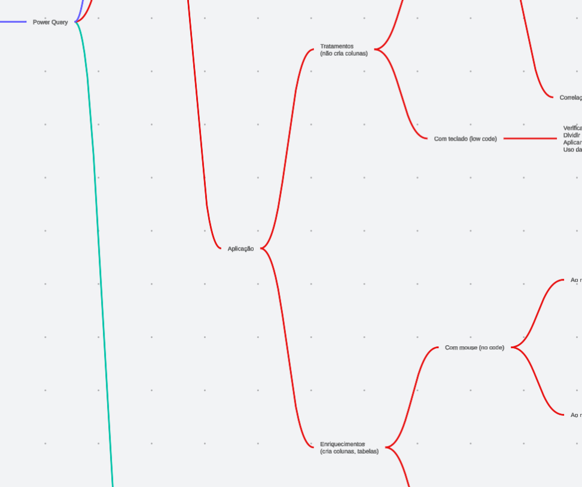

## 1️⃣ Ao nível de colunas

### 💡 Acessar nomes de coluna

🔹 O que faz?

```python
df_receitas.columns
```

```
Index(['Data Lançamento', 'Id Atendimento', 'Receita Código',
       'Quantidade Vendida', 'Valor de venda', 'Cliente ID', 'Cliente Sexo',
       'Cliente Nome', 'Cliente Data Nascimento', 'Cliente Origem',
       'Cliente Cidade', 'Profissional Nome', 'Profissional Especialidade',
       'Data de Pagamento', 'Forma Pagamento'],
      dtype='object')
```

### 💡 Mudar nomes de coluna

🔹 O que faz?

- A função .rename() permite alterar o nome de colunas específicas, sem modificar o restante.

```python
#permite passar um dicionário que atribue a cada coluna existente um novo nome

df_receitas = df_receitas.rename(columns={
    'Data Lançamento': 'data_lancamento',
    'Id Atendimento': 'atendimento_id',
    'Receita Código': 'receita_codigo',
    'Quantidade Vendida': 'venda_quantidade',
    'Valor de venda': 'venda_valor',
    'Cliente ID': 'cliente_id',
    'Cliente Sexo': 'cliente_sexo',
    'Cliente Nome':'cliente_nome',
    'Cliente Data Nascimento': 'cliente_nascimento_data',
    'Cliente Origem': 'cliente_origem',
    'Cliente Cidade': 'cliente_cidade',
    'Profissional Nome': 'profissional_nome',
    'Profissional Especialidade': 'profissional_especialidade',
    'Data de Pagamento': 'pagamento_data',
    'Forma Pagamento':'pagamento_forma'
    })
```

```python
df_receitas.columns
```

```
Index(['data_lancamento', 'atendimento_id', 'receita_codigo',
       'venda_quantidade', 'venda_valor', 'cliente_id', 'cliente_sexo',
       'cliente_nome', 'cliente_nascimento_data', 'cliente_origem',
       'cliente_cidade', 'profissional_nome', 'profissional_especialidade',
       'pagamento_data', 'pagamento_forma'],
      dtype='object')
```

🔹 Se quisermos alterar todos os nomes de uma vez, podemos usar a atribuição do nome das colunas, com df.columns = [...], mas tem que usar na mesma sequência da ordem atual das colunas

```python
#Usar a identação é uma boa prática

df_receitas.columns = ['data_lancamento',
                       'atendimento_id',
                       'receita_codigo',
                       'venda_quantidade',
                       'venda_valor',
                       'cliente_id',
                       'cliente_sexo',
                       'cliente_nome',
                       'cliente_nascimento_data',
                       'cliente_origem',
                       'cliente_cidade',
                       'profissional_nome',
                       'profissional_especialidade',
                       'pagamento_data',
                       'pagamento_forma'
                       ]
```

🔹 Se os nomes das colunas estiverem inconsistentes, podemos formatá-los automaticamente para minúsculo

```python
#df.columns = df.columns.str.lower()
```

🔹 Ou, se quisermos remover espaços e deixar padronizado:

```python
#df_receitas.columns = df_receitas.columns.str.strip().str.replace(" ", "_")
```

### 💡 Colocar a tipologia da coluna

Em planilhas, a alteração é com mouse (low-code, lembra da nossa aula de ferramentas?) Aqui é com o teclado

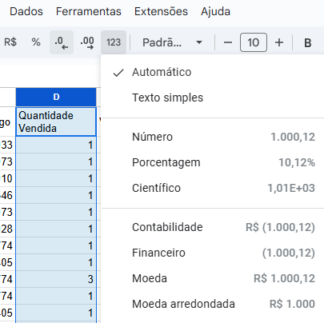

🔹 Ao trabalhar com dados, nem sempre as colunas vêm com o tipo correto. Por isso, é essencial converter os tipos das colunas para garantir análises e cálculos corretos.

🔹 Se uma coluna que deveria ser string foi carregada como número, podemos convertê-la usando a função astype

```python
df_receitas['atendimento_id'] = df_receitas['atendimento_id'].astype(str)
```

```python
# Converter tipo de dados de colunas
df_receitas['atendimento_id'] = df_receitas['atendimento_id'].astype(str) #Exemplo para string
df_receitas['receita_codigo'] = df_receitas['receita_codigo'].astype(str) #Exemplo para string
df_receitas['cliente_id'] = df_receitas['cliente_id'].astype(str) #Exemplo para string
```

🔹 Colunas de data muitas vezes são carregadas como object (texto), o que impede operações como cálculos de tempo. Por isso tem que ser convertidas usando a função to_datetime. É interessante usar parâmetros para forçar o formato e lidar com erros

```python
# Converter a coluna 'data_lancamento' para o tipo datetime
df_receitas['data_lancamento'] = pd.to_datetime(df_receitas['data_lancamento'], format='%Y/%m/%d', errors='coerce')

# Converter a coluna 'cliente_nascimento_data' para o tipo datetime
df_receitas['cliente_nascimento_data'] = pd.to_datetime(df_receitas['cliente_nascimento_data'], format='%Y/%m/%d', errors='coerce')

# Converter a coluna 'pagamento_data' para o tipo datetime
df_receitas['pagamento_data'] = pd.to_datetime(df_receitas['pagamento_data'], format='%Y/%m/%d', errors='coerce')
```

[Clique para ver a documentação](https://pandas.pydata.org/docs/reference/api/pandas.to_datetime.html)

### 💡 Mudar ordem das colunas

A ordem das colunas pode influenciar na organização e visualização dos dados. Em planilhas, a alteração é com mouse, basta arrastar (low-code, lembra da nossa aula de ferramentas?) Aqui é com o teclado high-code)!

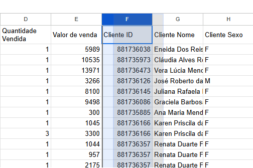

🔹 No Pandas, podemos facilmente alterar a ordem das colunas para facilitar a análise.

🔹 Antes de reordenar, é útil verificar a ordem atual:

```python
df_receitas.columns
```

```
Index(['data_lancamento', 'atendimento_id', 'receita_codigo',
       'venda_quantidade', 'venda_valor', 'cliente_id', 'cliente_sexo',
       'cliente_nome', 'cliente_nascimento_data', 'cliente_origem',
       'cliente_cidade', 'profissional_nome', 'profissional_especialidade',
       'pagamento_data', 'pagamento_forma'],
      dtype='object')
```

🔹 Podemos definir uma nova ordem das colunas especificando a sequência desejada:

```python
df_receitas = df_receitas[[
    "atendimento_id", "data_lancamento", "receita_codigo",
    "venda_quantidade", "venda_valor", "cliente_id", "cliente_sexo","cliente_nome",
    "cliente_nascimento_data", "cliente_origem",
    "cliente_cidade", "profissional_nome", "profissional_especialidade",
    "pagamento_data", "pagamento_forma"
]]
```

```python
df_receitas.columns
```

```
Index(['atendimento_id', 'data_lancamento', 'receita_codigo',
       'venda_quantidade', 'venda_valor', 'cliente_id', 'cliente_sexo',
       'cliente_nome', 'cliente_nascimento_data', 'cliente_origem',
       'cliente_cidade', 'profissional_nome', 'profissional_especialidade',
       'pagamento_data', 'pagamento_forma'],
      dtype='object')
```

🔹 Se quisermos organizar automaticamente as colunas em ordem alfabética:

```python
#df_receitas = df_receitas[sorted(df_receitas.columns)]
```

### 💡 Descartando uma coluna desnecessária

Em planilhas, a alteração é com mouse, basta clicar com o botão direito (low-code, lembra da nossa aula de ferramentas?) Aqui é com o teclado high-code)!

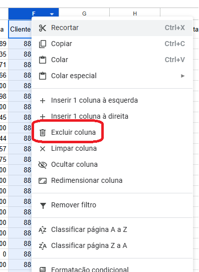

🔹 Em python, é possível descartar uma coluna simplesmente usando a atribuição anterior, deixando uma coluna de fora

🔹 Mas existem outras forma, usando a função drop(), especificando o nome da coluna

```python
df_receitas = df_receitas.drop(columns=["cliente_cidade"])
```

🔹 Se verificarmos com .columns, veremos que a coluna simplemente sumiu

```python
df_receitas.columns
```

```
Index(['atendimento_id', 'data_lancamento', 'receita_codigo',
       'venda_quantidade', 'venda_valor', 'cliente_id', 'cliente_sexo',
       'cliente_nome', 'cliente_nascimento_data', 'cliente_origem',
       'profissional_nome', 'profissional_especialidade', 'pagamento_data',
       'pagamento_forma'],
      dtype='object')
```

🔹 Se quiser jogar fora mais de uma coluna ao mesmo tempo, basta passar como parâmetro.

```python
df_receitas = df_receitas.drop(columns=["profissional_nome", "cliente_nome"])
```

🔹 Se não quisermos reatribuir o DataFrame (df_receitas = ...), podemos usar o parâmetro inplace=True. No entanto, cuidado com a sequência de aplicação (a sequência da receita importa!), porque você pode estar pedindo para jogar fora algo que já o foi

```python
df_receitas = df_receitas.drop(columns=["profissional_nome", "cliente_nome"], inplace=True)
```

[output not shown]

### 💡 Descartando uma coluna com nulidade

🔹 É possível descartar uma coluna com todos ou algum valor nulo, utlizando a função dropna()

```python
# axis = 1 identifica para dropar colunas
# how identifica o critério de nulidade

df_receitas = df_receitas.dropna(axis=1, how="all")
```

[Clique para ver documentação](https://pandas.pydata.org/docs/reference/api/pandas.DataFrame.dropna.html)